# Time Series Modelling of Neuronological data

```r
library(forecast)
library(MTS)
library(igraph)
library(vars)
library(tseries)
#install.packages("pracma")  # If not already installed
library(pracma)
```

```
[1] "Covariance matrix:"
          SSp.tr2.3  SSp.tr4  SSp.tr5 SSp.tr6a SSp.ll6a SSp.ll6b     cing      ccb      alv      CA1      CA3       LD       PO      VPM
SSp.tr2.3  4.69e-05 5.78e-05 5.07e-05 5.49e-05 5.44e-05 5.54e-05 5.01e-05 5.58e-05 3.42e-05 5.20e-05 5.08e-05 2.74e-05 3.66e-05 4.96e-05
SSp.tr4    5.78e-05 1.22e-04 6.96e-05 1.09e-04 1.13e-04 1.13e-04 1.00e-04 1.13e-04 7.93e-05 1.05e-04 9.02e-05 3.29e-05 4.43e-05 6.39e-05
SSp.tr5    5.07e-05 6.96e-05 6.00e-05 6.63e-05 6.54e-05 6.67e-05 6.06e-05 6.74e-05 4.26e-05 6.30e-05 6.10e-05 2.93e-05 3.92e-05 5.58e-05
SSp.tr6a   5.49e-05 1.09e-04 6.63e-05 3.98e-04 1.01e-04 1.24e-04 2.03e-04 2.99e-04 2.60e-04 2.47e-04 8.32e-05 3.23e-05 4.25e-05 6.08e-05
SSp.ll6a   5.44e-05 1.13e-04 6.54e-05 1.01e-04 1.06e-04 1.06e-04 9.35e-05 1.05e-04 7.38e-05 9.78e-05 8.47e-05 3.10e-05 4.18e-05 6.01e-05
SSp.ll6b   5.54e-05 1.13e-04 6.67e-05 1.24e-04 1.06e-04 1.30e-04 1.16e-04 1.30e-04 9.29e-05 1.21e-04 8.53e-05 3.19e-05 4.27e-05 6.12e-05
cing       5.01e-05 1.00e-04 6.06e-05 2.03e-04 9.35e-05 1.16e-04 1.92e-04 2.09e-04 1.61e-04 1.99e-04 7.62e-05 2.90e-05 3.86e-05 5.54e-05
ccb        5.58e-05 1.13e-04 6.74e-05 2.99e-04 1.05e-04 1.30e-04 2.09e-04 3.17e-04 2.08e-04 2.58e-04 8.52e-05 3.26e-05 4.31e-05 6.19e-05
alv        3.42e-05 7.93e-05 4.26e-05 2.60e-04 7.38e-05 9.29e-05 1.61e-04 2.08e-04 4.93e-04 1.98e-04 5.72e-05 1.93e-05 2.62e-05 3.84e-05
CA1        5.20e-05 1.05e-04 6.30e-05 2.47e-04 9.78e-05 1.21e-04 1.99e-04 2.58e-04 1.98e-04 2.42e-04 7.91e-05 3.02e-05 4.02e-05 5.77e-05
CA3        5.08e-05 9.02e-05 6.10e-05 8.32e-05 8.47e-05 8.53e-05 7.62e-05 8.52e-05 5.72e-05 7.91e-05 7.79e-05 2.92e-05 3.90e-05 5.61e-05
LD         2.74e-05 3.29e-05 2.93e-05 3.23e-05 3.10e-05 3.19e-05 2.90e-05 3.26e-05 1.93e-05 3.02e-05 2.92e-05 2.22e-05 2.47e-05 2.87e-05
PO         3.66e-05 4.43e-05 3.92e-05 4.25e-05 4.18e-05 4.27e-05 3.86e-05 4.31e-05 2.62e-05 4.02e-05 3.90e-05 2.47e-05 3.24e-05 3.84e-05
VPM        4.96e-05 6.39e-05 5.58e-05 6.08e-05 6.01e-05 6.12e-05 5.54e-05 6.19e-05 3.84e-05 5.77e-05 5.61e-05 2.87e-05 3.84e-05 5.44e-05
CCM at lag:  0
       [,1]  [,2]  [,3]  [,4]  [,5]  [,6]  [,7]  [,8]  [,9] [,10] [,11] [,12] [,13] [,14]
 [1,] 1.000 0.765 0.956 0.401 0.770 0.708 0.528 0.458 0.225 0.488 0.840 0.849 0.939 0.981
 [2,] 0.765 1.000 0.815 0.494 0.996 0.899 0.657 0.574 0.324 0.611 0.926 0.632 0.705 0.785
 [3,] 0.956 0.815 1.000 0.429 0.819 0.754 0.565 0.489 0.248 0.522 0.893 0.803 0.889 0.977
 [4,] 0.401 0.494 0.429 1.000 0.492 0.546 0.734 0.843 0.586 0.796 0.472 0.343 0.374 0.413
 [5,] 0.770 0.996 0.819 0.492 1.000 0.897 0.655 0.572 0.322 0.609 0.931 0.638 0.712 0.790
 [6,] 0.708 0.899 0.754 0.546 0.897 1.000 0.734 0.639 0.366 0.683 0.846 0.592 0.656 0.726
 [7,] 0.528 0.657 0.565 0.734 0.655 0.734 1.000 0.850 0.524 0.923 0.624 0.445 0.489 0.543
 [8,] 0.458 0.574 0.489 0.843 0.572 0.639 0.850 1.000 0.526 0.930 0.542 0.389 0.426 0.472
 [9,] 0.225 0.324 0.248 0.586 0.322 0.366 0.524 0.526 1.000 0.572 0.292 0.184 0.207 0.235
[10,] 0.488 0.611 0.522 0.796 0.609 0.683 0.923 0.930 0.572 1.000 0.576 0.412 0.454 0.502
[11,] 0.840 0.926 0.893 0.472 0.931 0.846 0.624 0.542 0.292 0.576 1.000 0.702 0.777 0.862
[12,] 0.849 0.632 0.803 0.343 0.638 0.592 0.445 0.389 0.184 0.412 0.702 1.000 0.921 0.825
[13,] 0.939 0.705 0.889 0.374 0.712 0.656 0.489 0.426 0.207 0.454 0.777 0.921 1.000 0.914
[14,] 0.981 0.785 0.977 0.413 0.790 0.726 0.543 0.472 0.235 0.502 0.862 0.825 0.914 1.000
Simplified matrix:
CCM at lag:  1
+ + + + + + + + + + + + + +
+ + + + + + + + + + + + + +
+ + + + + + + + + + + + + +
+ + + + + + + + + + + + + +
+ + + + + + + + + + + + + +
+ + + + + + + + + + + + + +
```

[output cut: 160 more lines]

```
+ + + + + + + + + + + + + +
+ + + + + + + + + + + + + +
+ + + + + + + + + + + + + +
+ + + + + + + + + + + + + +
+ + + + + + + + + + + + + +
+ + + + + + + + + + + + + +
+ + + + + + + + + + + + + +
+ + + + + + + + + + + + + +
+ + + + + + + + + + + + + +
+ + + + + + + + + + + + + +
+ + + + + + + + + + + + + +
+ + + + + + + + + + + + + +
+ + + + + + + + + + + + + +
[1] "Skip the plots due to high dimension!"
Hit Enter for p-value plot of individual ccm:
```

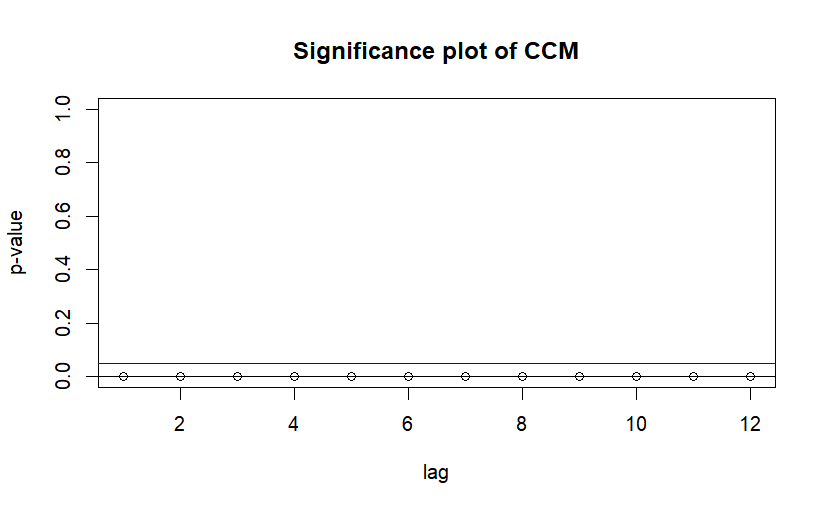

```r
firing_param15_Awake=read.csv("F:/mydata/IIT_J/mtech/project/sourav sirs papers/Time series modelling of 100 sequences/data/firing_param15_Awake.csv")


ccm(firing_param15_Awake)
```

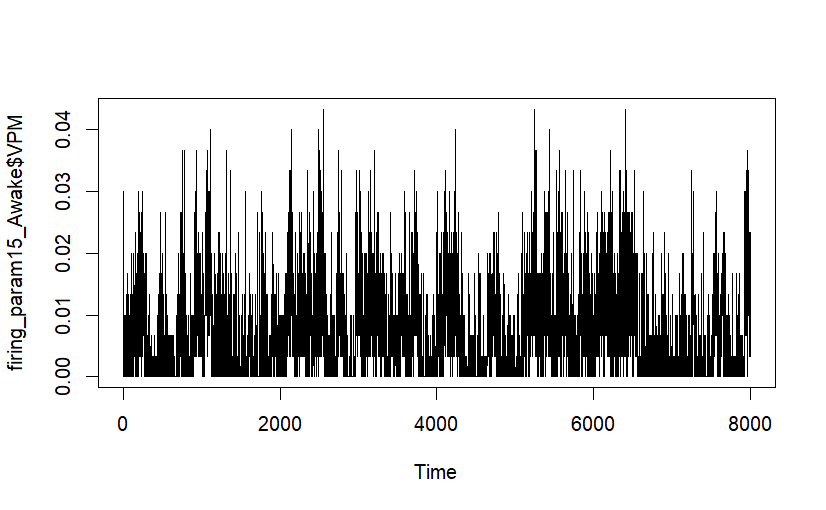

```r
ts.plot(firing_param15_Awake$VPM)
```

```r
NA
NA
NA
```

```r
t1=auto.arima(firing_param15_Awake$VPM)
summary(t1)
```

```
Series: firing_param15_Awake$VPM
ARIMA(1,1,2)

Coefficients:
         ar1      ma1     ma2
      0.4539  -1.1708  0.2409
s.e.  0.0688   0.0725  0.0620

sigma^2 = 3.326e-05:  log likelihood = 29890.78
AIC=-59773.57   AICc=-59773.56   BIC=-59745.62

Training set error measures:
                       ME        RMSE         MAE  MPE MAPE     MASE          ACF1
Training set 9.906933e-06 0.005765324 0.004239846 -Inf  Inf 0.874311 -0.0001151883
```

```r
t2=auto.arima(firing_param15_Awake$PO)
t3=auto.arima(firing_param15_Awake$LD)
summary(t2)
```

```
Series: firing_param15_Awake$PO
ARIMA(1,1,2)

Coefficients:
         ar1      ma1     ma2
      0.5857  -1.2447  0.2956
s.e.  0.0416   0.0461  0.0396

sigma^2 = 1.876e-05:  log likelihood = 32180.82
AIC=-64353.64   AICc=-64353.64   BIC=-64325.69

Training set error measures:
                       ME        RMSE         MAE  MPE MAPE      MASE        ACF1
Training set 9.067348e-06 0.004330029 0.003200052 -Inf  Inf 0.8812699 0.001823189
```

```r
summary(t3)
```

```
Series: firing_param15_Awake$LD
ARIMA(2,1,2)

Coefficients:
         ar1      ar2      ma1     ma2
      0.7561  -0.0414  -1.3800  0.4137
s.e.  0.0878   0.0338   0.0869  0.0793

sigma^2 = 1.217e-05:  log likelihood = 33913.3
AIC=-67816.61   AICc=-67816.6   BIC=-67781.67

Training set error measures:
                       ME        RMSE         MAE  MPE MAPE      MASE         ACF1
Training set 8.120886e-06 0.003486816 0.002619029 -Inf  Inf 0.8730502 0.0003701827
```

```r
Box.test(t1$residuals,type=c("Box-Pierce"))
```

```
    Box-Pierce test

data:  t1$residuals
X-squared = 0.00010615, df = 1, p-value = 0.9918
```

```r
Box.test(t2$residuals,type=c("Box-Pierce"))
```

```
    Box-Pierce test

data:  t2$residuals
X-squared = 0.026592, df = 1, p-value = 0.8705
```

```r
Box.test(t3$residuals,type=c("Box-Pierce"))
```

```
    Box-Pierce test

data:  t3$residuals
X-squared = 0.0010963, df = 1, p-value = 0.9736
```

```
Ljung-Box Statistics:
        m       Q(m)     df    p-value
 [1,]     1       493       9        0
 [2,]     2       740      18        0
 [3,]     3       973      27        0
 [4,]     4      1197      36        0
 [5,]     5      1372      45        0
 [6,]     6      1508      54        0
 [7,]     7      1624      63        0
 [8,]     8      1773      72        0
 [9,]     9      1914      81        0
[10,]    10      2035      90        0
[11,]    11      2142      99        0
[12,]    12      2250     108        0
[13,]    13      2370     117        0
[14,]    14      2511     126        0
[15,]    15      2633     135        0
[16,]    16      2782     144        0
[17,]    17      2942     153        0
[18,]    18      3101     162        0
[19,]    19      3211     171        0
[20,]    20      3332     180        0
[21,]    21      3462     189        0
[22,]    22      3575     198        0
[23,]    23      3654     207        0
[24,]    24      3750     216        0
```

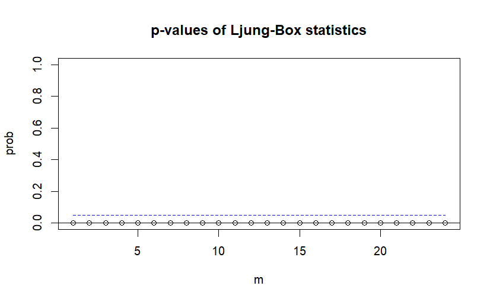

```r
VPM_awake_15=window(firing_param15_Awake$VPM,start = 1,end=1000)
LD_awake_15=window(firing_param15_Awake$LD,start = 1,end=1000)
PO_awake_15=window(firing_param15_Awake$PO,start = 1,end=1000)

df=firing_data=data.frame(VPM_awake_15,LD_awake_15,PO_awake_15)
colnames(firing_data)=c("VPM","LD","PO")
#var()
mq(df)
```

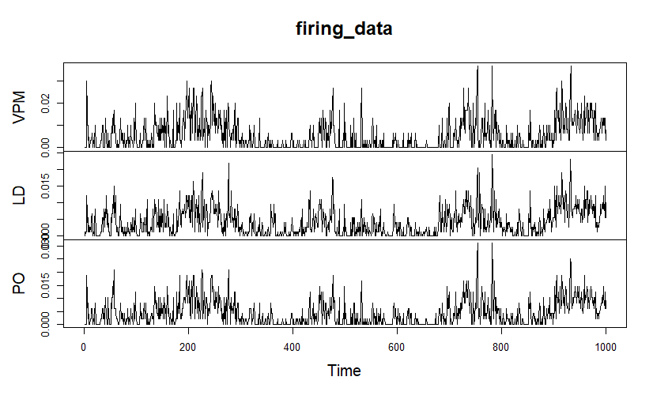

```r
#df
plot.ts(firing_data)
```

```r
adf.test(df$VPM_awake_15) # to check stationarity
```

```
    Augmented Dickey-Fuller Test

data:  df$VPM_awake_15
Dickey-Fuller = -5.0178, Lag order = 6, p-value = 0.01
alternative hypothesis: stationary
```

```r
adf.test(df$LD_awake_15)
```

```
    Augmented Dickey-Fuller Test

data:  df$LD_awake_15
Dickey-Fuller = -5.0571, Lag order = 6, p-value = 0.01
alternative hypothesis: stationary
```

```r
adf.test(df$PO_awake_15)
```

```
    Augmented Dickey-Fuller Test

data:  df$PO_awake_15
Dickey-Fuller = -4.964, Lag order = 6, p-value = 0.01
alternative hypothesis: stationary
```

🔍 **Quick Overview: Hurst Exponent (H)**  
The Hurst exponent $H \in (0, 1)$ gives insight into the **persistence** or **anti-persistence** of a time series:

| **H value** | **Interpretation** |
| --- | --- |
| $H = 0.5$ | Pure random walk (no memory) |
| $H < 0.5$ | Anti-persistent (mean-reverting) |
| $H > 0.5$ | Persistent (long-term positive autocorrelation) |

```r
hurstexp(df$VPM_awake_15)
```

```
Simple R/S Hurst estimation:         0.7606971
Corrected R over S Hurst exponent:   0.8945857
Empirical Hurst exponent:            0.9412303
Corrected empirical Hurst exponent:  0.9211222
Theoretical Hurst exponent:          0.5271195
```

✅ **Takeaway for `df$VPM_15_awake1`**:

```r
hurstexp(df$LD_awake_15)
```

```
Simple R/S Hurst estimation:         0.7652185
Corrected R over S Hurst exponent:   0.8805462
Empirical Hurst exponent:            0.9238575
Corrected empirical Hurst exponent:  0.9047762
Theoretical Hurst exponent:          0.5271195
```

```r
#hurstexp(df$PO_15_awake1)
```

```r
#hurstexp(df$LD_15_awake)
hurstexp(df$PO_awake_15)
```

```
Simple R/S Hurst estimation:         0.7662418
Corrected R over S Hurst exponent:   0.8888505
Empirical Hurst exponent:            0.9321951
Corrected empirical Hurst exponent:  0.9126846
Theoretical Hurst exponent:          0.5271195
```

```r
#VARorder(firing_param15_Awake)
VARorder(df)
```

```
selected order: aic =  10
selected order: bic =  5
selected order: hq =  9
Summary table:
       p      AIC      BIC       HQ      M(p) p-value
 [1,]  0 -34.5713 -34.5713 -34.5713    0.0000  0.0000
 [2,]  1 -35.1890 -35.1811 -35.1863 4948.3567  0.0000
 [3,]  2 -35.2750 -35.2593 -35.2696  704.5105  0.0000
 [4,]  3 -35.3028 -35.2792 -35.2947  239.7375  0.0000
 [5,]  4 -35.3252 -35.2938 -35.3145  196.6219  0.0000
 [6,]  5 -35.3364 -35.2971 -35.3230  107.1111  0.0000
 [7,]  6 -35.3431 -35.2959 -35.3269   70.9244  0.0000
 [8,]  7 -35.3446 -35.2896 -35.3258   30.4035  0.0004
 [9,]  8 -35.3470 -35.2841 -35.3255   37.0477  0.0000
[10,]  9 -35.3547 -35.2839 -35.3305   78.7078  0.0000
[11,] 10 -35.3555 -35.2769 -35.3286   24.4137  0.0037
[12,] 11 -35.3547 -35.2682 -35.3251   11.4280  0.2475
[13,] 12 -35.3538 -35.2595 -35.3215   11.1610  0.2648
[14,] 13 -35.3533 -35.2511 -35.3183   13.7873  0.1301
```

```r
#m1=VAR(firing_param15_Awake,p=1)
```

```r
m1=VAR(df,p=9)
```

```r
summary(m1)
```

[output not shown]

[output cut: 95 more lines]

```
F-statistic: 222.2 on 27 and 7963 DF,  p-value: < 2.2e-16



Covariance matrix of residuals:
             VPM_awake_15 LD_awake_15 PO_awake_15
VPM_awake_15    3.293e-05   1.464e-05   2.143e-05
LD_awake_15     1.464e-05   1.207e-05   1.303e-05
PO_awake_15     2.143e-05   1.303e-05   1.854e-05

Correlation matrix of residuals:
             VPM_awake_15 LD_awake_15 PO_awake_15
VPM_awake_15       1.0000      0.7343      0.8673
LD_awake_15        0.7343      1.0000      0.8710
PO_awake_15        0.8673      0.8710      1.0000
```

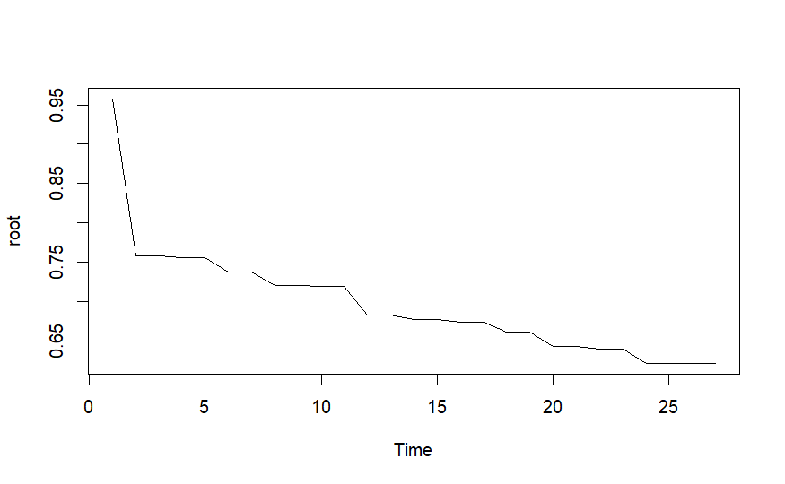

```r
root=vars::roots(m1)
#class(m1)
#m1%>%roots()
plot.ts(root)  ## roots are are <1 which implies satbility of the model
```

### Interpretation of `vars::roots(m1)` Output

- Each number represents the **modulus (absolute value) of the eigenvalues** of the companion matrix of your VAR model.
- For a VAR model to be **stable (stationary)**, all of these eigenvalue moduli must be **less than 1**.
- In your case, the **largest root is 0.9578**, which is below 1, so the stability condition is satisfied.

### Practical Implications

- **Impulse Response Functions (IRFs):** You can safely compute IRFs since the system is stable.
- **Forecasting:** The model can be used for reliable forecasting.
- **Granger Causality Analysis:** The dynamic relationships inferred from the model are meaningful, as the system does not exhibit explosive behavior.
- **Stationarity:** There is no need for further differencing or transformation—the ADF tests and the eigenvalue analysis both confirm stationarity.

Overall, your model is well-specified and meets the necessary stability criteria.

```r
serial.test(m1, type = "PT.adjusted")
```

```
    Portmanteau Test (adjusted)

data:  Residuals of VAR object m1
Chi-squared = 81.038, df = 63, p-value = 0.06262
```

```r
causality(m1,"VPM_awake_15")
```

```
$Granger

    Granger causality H0: VPM_awake_15 do not Granger-cause LD_awake_15 PO_awake_15

data:  VAR object m1
F-Test = 7.4043, df1 = 18, df2 = 23889, p-value < 2.2e-16


$Instant

    H0: No instantaneous causality between: VPM_awake_15 and LD_awake_15 PO_awake_15

data:  VAR object m1
Chi-squared = 3435.3, df = 2, p-value < 2.2e-16
```

```r
causality(m1,"LD_awake_15")
```

```
$Granger

    Granger causality H0: LD_awake_15 do not Granger-cause VPM_awake_15 PO_awake_15

data:  VAR object m1
F-Test = 5.9771, df1 = 18, df2 = 23889, p-value = 9.659e-15


$Instant

    H0: No instantaneous causality between: LD_awake_15 and VPM_awake_15 PO_awake_15

data:  VAR object m1
Chi-squared = 3451.7, df = 2, p-value < 2.2e-16
```

```r
causality(m1,"PO_awake_15")
```

```
$Granger

    Granger causality H0: PO_awake_15 do not Granger-cause VPM_awake_15 LD_awake_15

data:  VAR object m1
F-Test = 2.4635, df1 = 18, df2 = 23889, p-value = 0.0005196


$Instant

    H0: No instantaneous causality between: PO_awake_15 and VPM_awake_15 LD_awake_15

data:  VAR object m1
Chi-squared = 3720.4, df = 2, p-value < 2.2e-16
```

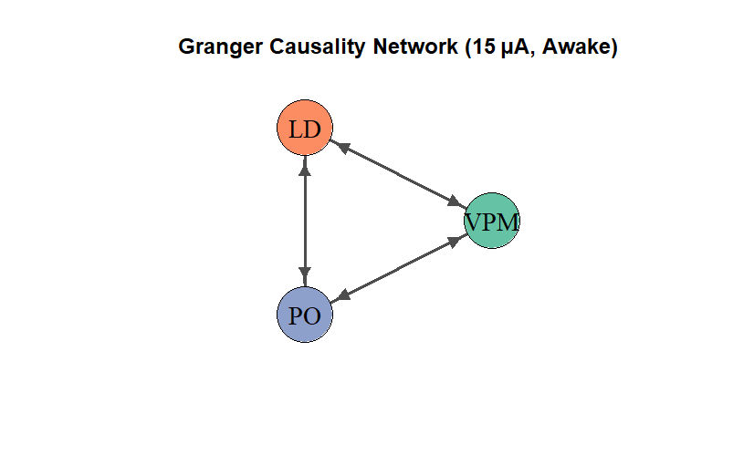

```r
# Load library
library(igraph)

# Define nodes and edges
nodes <- c("VPM", "LD", "PO")
edges <- c(
  "VPM", "LD",
  "VPM", "PO",
  "LD", "VPM",
  "LD", "PO",
  "PO", "VPM",
  "PO", "LD"
)

# Create directed graph
g <- graph_from_edgelist(matrix(edges, ncol = 2, byrow = TRUE), directed = TRUE)

# Define colors for clarity
vertex_colors <- c("VPM" = "#66c2a5", "LD" = "#fc8d62", "PO" = "#8da0cb")
edge_colors <- rep("gray30", ecount(g))

# Plot graph with enhancements
plot(g,
     vertex.size = 60,
     vertex.label.cex = 1.4,
     vertex.label.color = "black",
     vertex.color = vertex_colors[V(g)$name],
     edge.arrow.size = 0.9,
     edge.width = 2.5,
     edge.color = edge_colors,
     layout = layout_in_circle,
     main = "Granger Causality Network (15 μA, Awake)"
)
```

### firing_param15_ISO

```r
firing_param15_ISO=read.csv("F:/mydata/IIT_J/mtech/project/sourav sirs papers/Time series modelling of 100 sequences/data/firing_param15_ISO.csv")
```

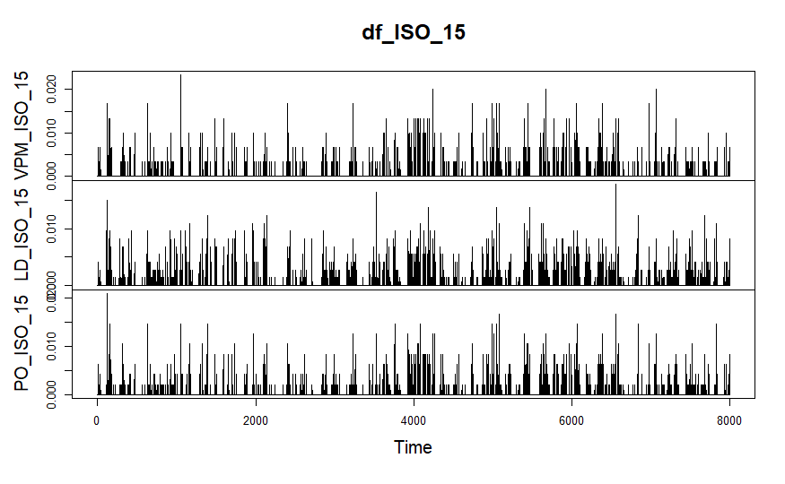

```r
VPM_ISO_15=window(firing_param15_ISO$VPM,start = 1,end=8000)
LD_ISO_15=window(firing_param15_ISO$LD,start = 1,end=8000)
PO_ISO_15=window(firing_param15_ISO$PO,start = 1,end=8000)

df_ISO_15=data.frame(VPM_ISO_15,LD_ISO_15,PO_ISO_15)

plot.ts(df_ISO_15)
```

```r
hurstexp(VPM_ISO_15)
```

```
Simple R/S Hurst estimation:         0.6650742
Corrected R over S Hurst exponent:   0.7285556
Empirical Hurst exponent:            0
Corrected empirical Hurst exponent:  0
Theoretical Hurst exponent:          0.5271195
```

```r
hurstexp(LD_ISO_15)
```

```
Simple R/S Hurst estimation:         0.6250353
Corrected R over S Hurst exponent:   0.6051633
Empirical Hurst exponent:            0
Corrected empirical Hurst exponent:  0
Theoretical Hurst exponent:          0.5271195
```

```r
hurstexp(PO_ISO_15)
```

```
Simple R/S Hurst estimation:         0.6637444
Corrected R over S Hurst exponent:   0.684213
Empirical Hurst exponent:            0
Corrected empirical Hurst exponent:  0
Theoretical Hurst exponent:          0.5271195
```

### Stationarity checks

```r
adf.test(df_ISO_15$VPM_ISO_15) # to check stationarity
```

```
    Augmented Dickey-Fuller Test

data:  df_ISO_15$VPM_ISO_15
Dickey-Fuller = -16.585, Lag order = 19, p-value = 0.01
alternative hypothesis: stationary
```

```r
adf.test(df_ISO_15$LD_ISO_15)
```

```
    Augmented Dickey-Fuller Test

data:  df_ISO_15$LD_ISO_15
Dickey-Fuller = -16.807, Lag order = 19, p-value = 0.01
alternative hypothesis: stationary
```

```r
adf.test(df_ISO_15$PO_ISO_15)
```

```
    Augmented Dickey-Fuller Test

data:  df_ISO_15$PO_ISO_15
Dickey-Fuller = -16.874, Lag order = 19, p-value = 0.01
alternative hypothesis: stationary
```

```r
#var()
```

### Multivariate LJung Box Test

```
Ljung-Box Statistics:
        m       Q(m)     df    p-value
 [1,]     1      2440       9        0
 [2,]     2      2854      18        0
 [3,]     3      2994      27        0
 [4,]     4      3038      36        0
 [5,]     5      3069      45        0
 [6,]     6      3105      54        0
 [7,]     7      3170      63        0
 [8,]     8      3247      72        0
 [9,]     9      3294      81        0
[10,]    10      3316      90        0
[11,]    11      3346      99        0
[12,]    12      3376     108        0
[13,]    13      3413     117        0
[14,]    14      3447     126        0
[15,]    15      3491     135        0
[16,]    16      3510     144        0
[17,]    17      3529     153        0
[18,]    18      3565     162        0
[19,]    19      3591     171        0
[20,]    20      3607     180        0
[21,]    21      3628     189        0
[22,]    22      3647     198        0
[23,]    23      3700     207        0
[24,]    24      3774     216        0
```

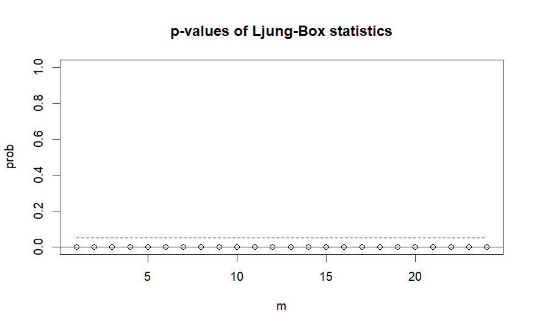

```r
mq(df_ISO_15)
```

```
[1] "Covariance matrix:"
           VPM_ISO_15 LD_ISO_15 PO_ISO_15
VPM_ISO_15   2.96e-06  1.50e-06  2.18e-06
LD_ISO_15    1.50e-06  2.32e-06  1.82e-06
PO_ISO_15    2.18e-06  1.82e-06  2.41e-06
CCM at lag:  0
      [,1]  [,2]  [,3]
[1,] 1.000 0.574 0.817
[2,] 0.574 1.000 0.767
[3,] 0.817 0.767 1.000
Simplified matrix:
CCM at lag:  1
+ + +
+ + +
+ + +
CCM at lag:  2
+ + +
+ + +
+ + +
CCM at lag:  3
. . .
+ + +
+ + +
CCM at lag:  4
. . .
+ + +
+ + +
CCM at lag:  5
. . .
+ + +
. + +
CCM at lag:  6
. + +
+ + +
+ + +
CCM at lag:  7
+ + +
+ + +
+ + +
CCM at lag:  8
+ + +
+ + +
+ + +
CCM at lag:  9
+ + +
+ + +
+ + +
CCM at lag:  10
. + .
. + .
. + .
CCM at lag:  11
+ + +
+ + +
. + +
CCM at lag:  12
+ + +
+ + +
+ + +
Hit Enter for p-value plot of individual ccm:
```

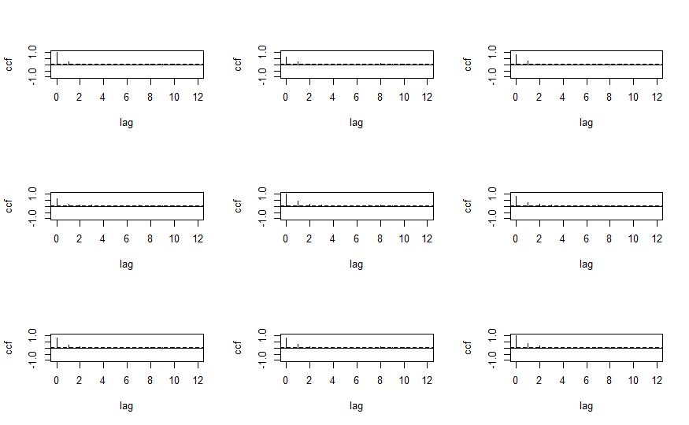

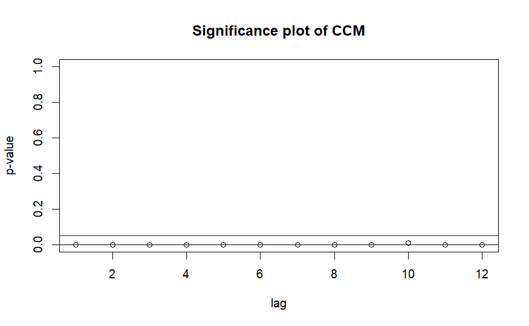

```r
ccm(df_ISO_15)
```

```r
VARorder(df_ISO_15)
```

```
selected order: aic =  8
selected order: bic =  2
selected order: hq =  3
Summary table:
       p      AIC      BIC       HQ      M(p) p-value
 [1,]  0 -40.6525 -40.6525 -40.6525    0.0000  0.0000
 [2,]  1 -40.9794 -40.9716 -40.9768 2628.0275  0.0000
 [3,]  2 -40.9959 -40.9802 -40.9905  149.1152  0.0000
 [4,]  3 -40.9994 -40.9758 -40.9913   45.6799  0.0000
 [5,]  4 -40.9985 -40.9670 -40.9877   10.9037  0.2824
 [6,]  5 -40.9987 -40.9594 -40.9853   20.0184  0.0178
 [7,]  6 -40.9982 -40.9511 -40.9821   13.9150  0.1254
 [8,]  7 -41.0002 -40.9451 -40.9813   33.3030  0.0001
 [9,]  8 -41.0022 -40.9393 -40.9807   34.2420  0.0001
[10,]  9 -41.0017 -40.9310 -40.9775   13.9228  0.1251
[11,] 10 -41.0001 -40.9214 -40.9731    4.6677  0.8623
[12,] 11 -40.9996 -40.9131 -40.9700   13.9560  0.1239
[13,] 12 -40.9985 -40.9042 -40.9663    9.7979  0.3671
[14,] 13 -40.9984 -40.8962 -40.9634   16.5544  0.0562
```

```r
model_ISO_15=VAR(df_ISO_15,p=13)
```

```r
summary(model_ISO_15)
```

```
VAR Estimation Results:
=========================
Endogenous variables: VPM_ISO_15, LD_ISO_15, PO_ISO_15
Deterministic variables: const
Sample size: 7987
Log Likelihood: 129844.627
Roots of the characteristic polynomial:
0.8714 0.8073 0.8073 0.7925 0.7925 0.7756 0.7756 0.7658 0.7658 0.7653 0.7653 0.7649 0.7649 0.758 0.758 0.7508 0.7508 0.7432 0.7432 0.7371 0.7371 0.7334 0.7334 0.7271 0.7271 0.7269 0.7269 0.7167 0.7167 0.716 0.716 0.7118 0.7118 0.7038 0.7038 0.7008 0.6932 0.6932 0.4129
Call:
VAR(y = df_ISO_15, p = 13)


Estimation results for equation VPM_ISO_15:
===========================================
VPM_ISO_15 = VPM_ISO_15.l1 + LD_ISO_15.l1 + PO_ISO_15.l1 + VPM_ISO_15.l2 + LD_ISO_15.l2 + PO_ISO_15.l2 + VPM_ISO_15.l3 + LD_ISO_15.l3 + PO_ISO_15.l3 + VPM_ISO_15.l4 + LD_ISO_15.l4 + PO_ISO_15.l4 + VPM_ISO_15.l5 + LD_ISO_15.l5 + PO_ISO_15.l5 + VPM_ISO_15.l6 + LD_ISO_15.l6 + PO_ISO_15.l6 + VPM_ISO_15.…

                 Estimate Std. Error t value Pr(>|t|)
VPM_ISO_15.l1   1.019e-01  1.931e-02   5.278 1.34e-07 ***
LD_ISO_15.l1    2.685e-02  2.067e-02   1.299 0.193916
PO_ISO_15.l1    1.849e-01  2.749e-02   6.728 1.84e-11 ***
VPM_ISO_15.l2  -6.647e-02  1.963e-02  -3.385 0.000715 ***
LD_ISO_15.l2   -7.414e-02  2.232e-02  -3.321 0.000900 ***
PO_ISO_15.l2    8.515e-02  2.836e-02   3.002 0.002689 **
VPM_ISO_15.l3  -1.069e-02  1.965e-02  -0.544 0.586542
LD_ISO_15.l3   -4.689e-03  2.236e-02  -0.210 0.833882
PO_ISO_15.l3   -2.217e-02  2.841e-02  -0.780 0.435195
VPM_ISO_15.l4  -1.986e-02  1.968e-02  -1.009 0.312928
LD_ISO_15.l4    1.091e-02  2.236e-02   0.488 0.625594
PO_ISO_15.l4    1.996e-02  2.844e-02   0.702 0.482792
VPM_ISO_15.l5  -2.631e-02  1.969e-02  -1.336 0.181567
LD_ISO_15.l5   -1.528e-02  2.236e-02  -0.684 0.494285
PO_ISO_15.l5    3.747e-02  2.844e-02   1.317 0.187739
VPM_ISO_15.l6   2.228e-02  1.972e-02   1.130 0.258509
LD_ISO_15.l6    1.442e-02  2.237e-02   0.645 0.519212
PO_ISO_15.l6   -2.955e-02  2.846e-02  -1.038 0.299155
VPM_ISO_15.l7   1.595e-02  1.972e-02   0.809 0.418649
LD_ISO_15.l7   -1.360e-02  2.236e-02  -0.608 0.542943
PO_ISO_15.l7    1.992e-02  2.846e-02   0.700 0.483989
VPM_ISO_15.l8   3.237e-02  1.972e-02   1.641 0.100839
LD_ISO_15.l8    7.935e-02  2.236e-02   3.549 0.000389 ***
```

[output cut: 131 more lines]

```
F-statistic: 31.52 on 39 and 7947 DF,  p-value: < 2.2e-16



Covariance matrix of residuals:
           VPM_ISO_15 LD_ISO_15 PO_ISO_15
VPM_ISO_15  2.708e-06 1.298e-06 1.934e-06
LD_ISO_15   1.298e-06 1.887e-06 1.505e-06
PO_ISO_15   1.934e-06 1.505e-06 2.097e-06

Correlation matrix of residuals:
           VPM_ISO_15 LD_ISO_15 PO_ISO_15
VPM_ISO_15     1.0000    0.5742    0.8119
LD_ISO_15      0.5742    1.0000    0.7567
PO_ISO_15      0.8119    0.7567    1.0000
```

```r
# model statbility
vars::roots(model_ISO_15)
```

```
 [1] 0.8714455 0.8073050 0.8073050 0.7925499 0.7925499 0.7756040 0.7756040 0.7658392 0.7658392 0.7652725 0.7652725 0.7649007 0.7649007
[14] 0.7579582 0.7579582 0.7508236 0.7508236 0.7432096 0.7432096 0.7370548 0.7370548 0.7333978 0.7333978 0.7271373 0.7271373 0.7269066
[27] 0.7269066 0.7167390 0.7167390 0.7159893 0.7159893 0.7118177 0.7118177 0.7037771 0.7037771 0.7007564 0.6931889 0.6931889 0.4128964
```

```r
serial.test(model_ISO_15)
```

```
    Portmanteau Test (asymptotic)

data:  Residuals of VAR object model_ISO_15
Chi-squared = 38.64, df = 27, p-value = 0.06829
```

```r
causality(model_ISO_15,"VPM_ISO_15")
```

```
$Granger

    Granger causality H0: VPM_ISO_15 do not Granger-cause LD_ISO_15 PO_ISO_15

data:  VAR object model_ISO_15
F-Test = 2.3791, df1 = 26, df2 = 23841, p-value = 9.539e-05


$Instant

    H0: No instantaneous causality between: VPM_ISO_15 and LD_ISO_15 PO_ISO_15

data:  VAR object model_ISO_15
Chi-squared = 3183.9, df = 2, p-value < 2.2e-16
```

```r
causality(model_ISO_15,"LD_ISO_15")
```

```
$Granger

    Granger causality H0: LD_ISO_15 do not Granger-cause VPM_ISO_15 PO_ISO_15

data:  VAR object model_ISO_15
F-Test = 6.4408, df1 = 26, df2 = 23841, p-value < 2.2e-16


$Instant

    H0: No instantaneous causality between: LD_ISO_15 and VPM_ISO_15 PO_ISO_15

data:  VAR object model_ISO_15
Chi-squared = 2923.5, df = 2, p-value < 2.2e-16
```

```r
causality(model_ISO_15,"PO_ISO_15")
```

```
$Granger

    Granger causality H0: PO_ISO_15 do not Granger-cause VPM_ISO_15 LD_ISO_15

data:  VAR object model_ISO_15
F-Test = 5.7877, df1 = 26, df2 = 23841, p-value < 2.2e-16


$Instant

    H0: No instantaneous causality between: PO_ISO_15 and VPM_ISO_15 LD_ISO_15

data:  VAR object model_ISO_15
Chi-squared = 3512.6, df = 2, p-value < 2.2e-16
```

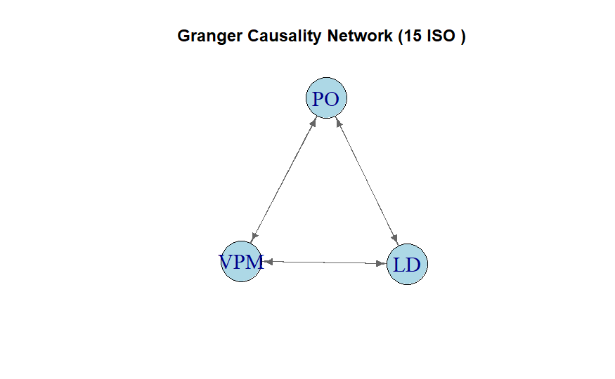

```r
# Define simplified nodes and edges
nodes <- c("VPM", "LD", "PO")
edges <- c("VPM", "LD",
           "VPM", "PO",
           "LD", "VPM",
           "LD", "PO",
           "PO", "VPM",
           "PO", "LD")

# Create a directed graph
g <- graph(edges = edges, directed = TRUE)

# Plot the graph
plot(g,
     vertex.color = "lightblue",
     vertex.size = 50,
     vertex.label.cex = 1.5,
     edge.arrow.size = 0.6,
     edge.color = "gray40",
     main = "Granger Causality Network (15 ISO ) ")
```

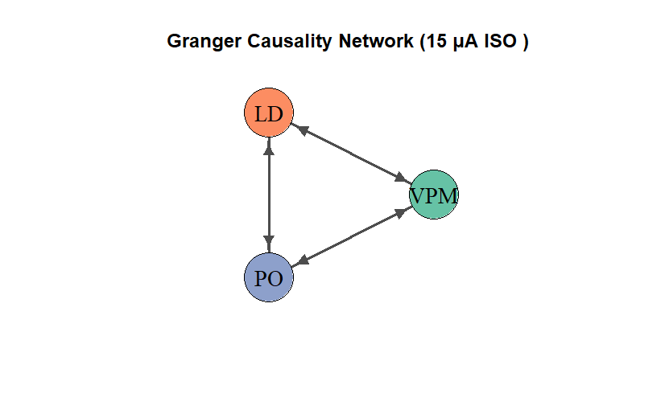

```r
# Load library
library(igraph)

# Define nodes and edges
nodes <- c("VPM", "LD", "PO")
edges <- c(
  "VPM", "LD",
  "VPM", "PO",
  "LD", "VPM",
  "LD", "PO",
  "PO", "VPM",
  "PO", "LD"
)

# Create directed graph
g <- graph_from_edgelist(matrix(edges, ncol = 2, byrow = TRUE), directed = TRUE)

# Define colors for clarity
vertex_colors <- c("VPM" = "#66c2a5", "LD" = "#fc8d62", "PO" = "#8da0cb")
edge_colors <- rep("gray30", ecount(g))

# Plot graph with enhancements
plot(g,
     vertex.size = 60,
     vertex.label.cex = 1.4,
     vertex.label.color = "black",
     vertex.color = vertex_colors[V(g)$name],
     edge.arrow.size = 0.9,
     edge.width = 2.5,
     edge.color = edge_colors,
     layout = layout_in_circle,
     main = "Granger Causality Network (15 μA ISO ) "
)
```

### firing_param15_Recovery

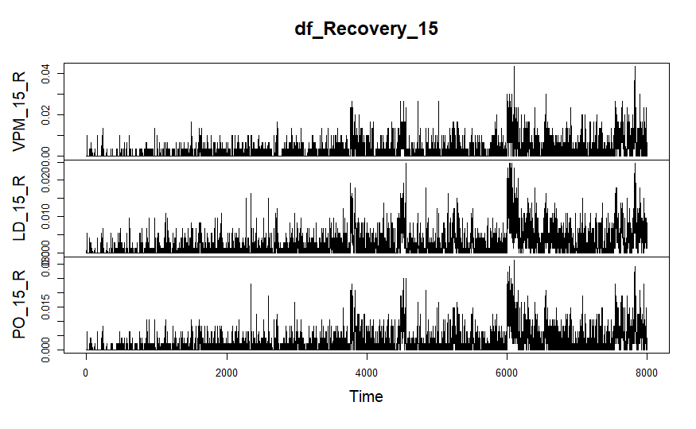

```r
firing_param15_Recovery=read.csv("F:/mydata/IIT_J/mtech/project/sourav sirs papers/Time series modelling of 100 sequences/data/firing_param15_Recovery.csv")

VPM_15_R=firing_param15_Recovery$VPM
LD_15_R=firing_param15_Recovery$LD
PO_15_R=firing_param15_Recovery$PO


df_Recovery_15=data.frame(VPM_15_R,LD_15_R,PO_15_R)

plot.ts(df_Recovery_15)
```

```r
hurstexp(df_Recovery_15$VPM_15_R)
```

```
Simple R/S Hurst estimation:         0.790197
Corrected R over S Hurst exponent:   0.9438397
Empirical Hurst exponent:            0.8885328
Corrected empirical Hurst exponent:  0.8655256
Theoretical Hurst exponent:          0.5271195
```

```r
hurstexp(df_Recovery_15$LD_15_R)
```

```
Simple R/S Hurst estimation:         0.8087535
Corrected R over S Hurst exponent:   0.9331003
Empirical Hurst exponent:            0.8698711
Corrected empirical Hurst exponent:  0.850732
Theoretical Hurst exponent:          0.5271195
```

```r
hurstexp(df_Recovery_15$PO_15_R)
```

```
Simple R/S Hurst estimation:         0.8028342
Corrected R over S Hurst exponent:   0.9397895
Empirical Hurst exponent:            0.8877794
Corrected empirical Hurst exponent:  0.8665922
Theoretical Hurst exponent:          0.5271195
```

```r
VARorder(df_Recovery_15)
```

```
selected order: aic =  11
selected order: bic =  5
selected order: hq =  8
Summary table:
       p      AIC      BIC       HQ      M(p) p-value
 [1,]  0 -36.7865 -36.7865 -36.7865    0.0000  0.0000
 [2,]  1 -37.5044 -37.4966 -37.5017 5748.6481  0.0000
 [3,]  2 -37.6119 -37.5962 -37.6065  875.3774  0.0000
 [4,]  3 -37.6558 -37.6322 -37.6477  368.1550  0.0000
 [5,]  4 -37.6763 -37.6449 -37.6656  181.7150  0.0000
 [6,]  5 -37.6844 -37.6451 -37.6709   82.3019  0.0000
 [7,]  6 -37.6911 -37.6440 -37.6750   71.5128  0.0000
 [8,]  7 -37.6977 -37.6427 -37.6789   70.6932  0.0000
 [9,]  8 -37.7038 -37.6409 -37.6823   66.3593  0.0000
[10,]  9 -37.7051 -37.6344 -37.6809   28.0242  0.0009
[11,] 10 -37.7076 -37.6290 -37.6807   38.1235  0.0000
[12,] 11 -37.7090 -37.6225 -37.6794   28.6228  0.0008
[13,] 12 -37.7085 -37.6142 -37.6762   14.1913  0.1157
[14,] 13 -37.7075 -37.6054 -37.6726   10.0320  0.3479
```

```r
#model_Recovery_15=VARMA(df_Recovery_15,p=5,q=1)
#serial.test(model_Recovery_15)



library(MTS)

#reduced_data=data.frame()
# Assuming you've already fit your VARMA model:
#VARorder(reduced_data)
#model_Recovery_15=VAR(reduced_data,p=8)
model_Recovery_15 <- VAR(df_Recovery_15, p=11)
```

```r
# Check residual diagnostics
#mq(model_Recovery_15)


serial.test(model_Recovery_15)
```

```
    Portmanteau Test (asymptotic)

data:  Residuals of VAR object model_Recovery_15
Chi-squared = 72.185, df = 45, p-value = 0.006204
```

```r
#MTSdiag(model_Recovery_15)
```

```r
summary(model_Recovery_15)
```

```
VAR Estimation Results:
=========================
Endogenous variables: VPM_15_R, LD_15_R, PO_15_R
Deterministic variables: const
Sample size: 7989
Log Likelihood: 116722.63
Roots of the characteristic polynomial:
0.9687 0.8592 0.7859 0.7859 0.7712 0.7712 0.7631 0.7631 0.7583 0.7583 0.7478 0.7478 0.7388 0.7388 0.7356 0.7356 0.7298 0.7298 0.724 0.724 0.7182 0.7182 0.7053 0.7053 0.6853 0.6853 0.678 0.678 0.6635 0.6455 0.6455 0.3645 0.3645
Call:
VAR(y = df_Recovery_15, p = 11)


Estimation results for equation VPM_15_R:
=========================================
VPM_15_R = VPM_15_R.l1 + LD_15_R.l1 + PO_15_R.l1 + VPM_15_R.l2 + LD_15_R.l2 + PO_15_R.l2 + VPM_15_R.l3 + LD_15_R.l3 + PO_15_R.l3 + VPM_15_R.l4 + LD_15_R.l4 + PO_15_R.l4 + VPM_15_R.l5 + LD_15_R.l5 + PO_15_R.l5 + VPM_15_R.l6 + LD_15_R.l6 + PO_15_R.l6 + VPM_15_R.l7 + LD_15_R.l7 + PO_15_R.l7 + VPM_15_R.…

               Estimate Std. Error t value Pr(>|t|)
VPM_15_R.l1   1.693e-01  1.898e-02   8.920  < 2e-16 ***
LD_15_R.l1    1.043e-01  3.040e-02   3.431 0.000603 ***
PO_15_R.l1    8.344e-02  3.306e-02   2.524 0.011626 *
VPM_15_R.l2   4.440e-02  1.930e-02   2.300 0.021453 *
LD_15_R.l2    1.255e-02  3.143e-02   0.399 0.689767
PO_15_R.l2    6.908e-02  3.340e-02   2.068 0.038669 *
VPM_15_R.l3   7.046e-02  1.931e-02   3.648 0.000266 ***
LD_15_R.l3    7.187e-02  3.158e-02   2.276 0.022877 *
PO_15_R.l3   -2.359e-02  3.349e-02  -0.704 0.481205
VPM_15_R.l4   4.374e-02  1.932e-02   2.264 0.023585 *
LD_15_R.l4   -7.177e-03  3.169e-02  -0.227 0.820801
PO_15_R.l4    2.009e-02  3.353e-02   0.599 0.549119
VPM_15_R.l5   1.940e-02  1.932e-02   1.004 0.315353
LD_15_R.l5    1.255e-02  3.172e-02   0.396 0.692408
PO_15_R.l5   -2.744e-03  3.355e-02  -0.082 0.934798
VPM_15_R.l6   2.322e-02  1.933e-02   1.201 0.229630
LD_15_R.l6   -4.029e-02  3.174e-02  -1.269 0.204415
PO_15_R.l6    3.693e-02  3.357e-02   1.100 0.271306
VPM_15_R.l7   3.409e-02  1.933e-02   1.764 0.077761 .
LD_15_R.l7    1.115e-02  3.174e-02   0.351 0.725276
PO_15_R.l7    1.724e-02  3.355e-02   0.514 0.607292
VPM_15_R.l8   7.779e-02  1.932e-02   4.026 5.73e-05 ***
LD_15_R.l8    8.670e-02  3.171e-02   2.734 0.006268 **
```

[output cut: 113 more lines]

```
F-statistic: 226.2 on 33 and 7955 DF,  p-value: < 2.2e-16



Covariance matrix of residuals:
          VPM_15_R   LD_15_R   PO_15_R
VPM_15_R 1.098e-05 4.914e-06 7.164e-06
LD_15_R  4.914e-06 5.194e-06 5.159e-06
PO_15_R  7.164e-06 5.159e-06 7.207e-06

Correlation matrix of residuals:
         VPM_15_R LD_15_R PO_15_R
VPM_15_R   1.0000  0.6507  0.8052
LD_15_R    0.6507  1.0000  0.8431
PO_15_R    0.8052  0.8431  1.0000
```

```r
causality(model_Recovery_15,"VPM_15_R")
```

```
$Granger

    Granger causality H0: VPM_15_R do not Granger-cause LD_15_R PO_15_R

data:  VAR object model_Recovery_15
F-Test = 4.8813, df1 = 22, df2 = 23865, p-value = 3.487e-13


$Instant

    H0: No instantaneous causality between: VPM_15_R and LD_15_R PO_15_R

data:  VAR object model_Recovery_15
Chi-squared = 3150.6, df = 2, p-value < 2.2e-16
```

```r
causality(model_Recovery_15,"LD_15_R")
```

```
$Granger

    Granger causality H0: LD_15_R do not Granger-cause VPM_15_R PO_15_R

data:  VAR object model_Recovery_15
F-Test = 9.0221, df1 = 22, df2 = 23865, p-value < 2.2e-16


$Instant

    H0: No instantaneous causality between: LD_15_R and VPM_15_R PO_15_R

data:  VAR object model_Recovery_15
Chi-squared = 3325.6, df = 2, p-value < 2.2e-16
```

```r
causality(model_Recovery_15,"PO_15_R")
```

```
$Granger

    Granger causality H0: PO_15_R do not Granger-cause VPM_15_R LD_15_R

data:  VAR object model_Recovery_15
F-Test = 3.3821, df1 = 22, df2 = 23865, p-value = 1.358e-07


$Instant

    H0: No instantaneous causality between: PO_15_R and VPM_15_R LD_15_R

data:  VAR object model_Recovery_15
Chi-squared = 3611.7, df = 2, p-value < 2.2e-16
```

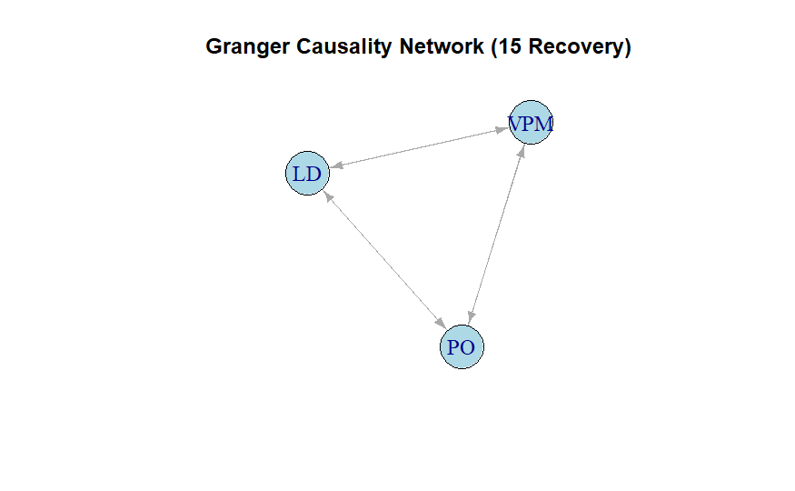

```r
# Required libraries
library(igraph)

# Define nodes
nodes <- c("VPM", "LD", "PO")

# Define edges with significant Granger causality (p < 0.05)
# Format: from -> to
edges <- c(
  "VPM", "LD",
  "VPM", "PO",
  "LD", "VPM",
  "LD", "PO",
  "PO", "VPM",
  "PO", "LD"
)

# Create a directed graph
g <- graph_from_edgelist(matrix(edges, ncol = 2, byrow = TRUE), directed = TRUE)

# Plot the graph
plot(g,
     vertex.size = 40,
     vertex.label.cex = 1.2,
     vertex.color = "lightblue",
     edge.arrow.size = 0.6,
     main = "Granger Causality Network (15 Recovery)")
```

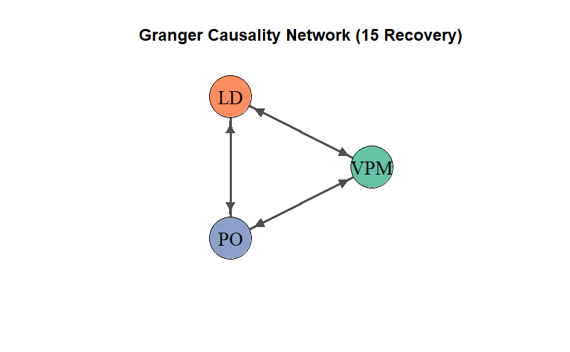

```r
# Load library
library(igraph)

# Define nodes and edges
nodes <- c("VPM", "LD", "PO")
edges <- c(
  "VPM", "LD",
  "VPM", "PO",
  "LD", "VPM",
  "LD", "PO",
  "PO", "VPM",
  "PO", "LD"
)

# Create directed graph
g <- graph_from_edgelist(matrix(edges, ncol = 2, byrow = TRUE), directed = TRUE)

# Define colors for clarity
vertex_colors <- c("VPM" = "#66c2a5", "LD" = "#fc8d62", "PO" = "#8da0cb")
edge_colors <- rep("gray30", ecount(g))

# Plot graph with enhancements
plot(g,
     vertex.size = 60,
     vertex.label.cex = 1.4,
     vertex.label.color = "black",
     vertex.color = vertex_colors[V(g)$name],
     edge.arrow.size = 0.9,
     edge.width = 2.5,
     edge.color = edge_colors,
     layout = layout_in_circle,
     main = "Granger Causality Network (15 Recovery)"
)
```

### For parameter 35

```r
# Read the CSV file
firing_param35_Awake <- read.csv("F:/mydata/IIT_J/mtech/project/sourav sirs papers/Time series modelling of 100 sequences/data/firing_param35_Awake.csv")

# Create a new data frame with specific columns
df_Awake_35 <- data.frame(
  VPM = firing_param35_Awake$VPM,
  LD = firing_param35_Awake$LD,
  PO = firing_param35_Awake$PO
)

# Set column names explicitly if needed
colnames(df_Awake_35) <- c("VPM_35_A", "LD_35_A", "PO_35_A")

df_Awake_35
```

| VPM_35_A | LD_35_A | PO_35_A |
| --- | --- | --- |
| 0.000000000 | 0.000000000 | 0.000000000 |
| 0.013333333 | 0.006849315 | 0.008333333 |
| 0.000000000 | 0.002739726 | 0.002083333 |
| 0.006666667 | 0.004109589 | 0.004166667 |
| 0.006666667 | 0.002739726 | 0.004166667 |
| 0.003333333 | 0.004109589 | 0.004166667 |
| 0.003333333 | 0.002739726 | 0.004166667 |
| 0.000000000 | 0.001369863 | 0.000000000 |
| 0.010000000 | 0.005479452 | 0.008333333 |
| 0.010000000 | 0.006849315 | 0.010416667 |

[output cut: 990 more lines]

```r
NA
```

### Hurtexp for longterm dependences

```r
hurstexp(df_Awake_35$VPM_35_A)
```

```
Simple R/S Hurst estimation:         0.7042551
Corrected R over S Hurst exponent:   0.8227821
Empirical Hurst exponent:            0.9093723
Corrected empirical Hurst exponent:  0.8882778
Theoretical Hurst exponent:          0.5271195
```

```r
hurstexp(df_Awake_35$LD_35_A)
```

```
Simple R/S Hurst estimation:         0.6778227
Corrected R over S Hurst exponent:   0.768144
Empirical Hurst exponent:            0.8345413
Corrected empirical Hurst exponent:  0.8154433
Theoretical Hurst exponent:          0.5271195
```

```r
hurstexp(df_Awake_35$PO_35_A)
```

```
Simple R/S Hurst estimation:         0.6902318
Corrected R over S Hurst exponent:   0.7941211
Empirical Hurst exponent:            0.8741552
Corrected empirical Hurst exponent:  0.853493
Theoretical Hurst exponent:          0.5271195
```

```r
VARorder(df_Awake_35)
```

```
selected order: aic =  13
selected order: bic =  5
selected order: hq =  9
Summary table:
       p      AIC      BIC       HQ      M(p) p-value
 [1,]  0 -33.1369 -33.1369 -33.1369    0.0000   0e+00
 [2,]  1 -33.7489 -33.7410 -33.7462 4903.0114   0e+00
 [3,]  2 -33.7680 -33.7522 -33.7626  170.0334   0e+00
 [4,]  3 -33.7759 -33.7523 -33.7678   81.0990   0e+00
 [5,]  4 -33.7881 -33.7567 -33.7774  115.8248   0e+00
 [6,]  5 -33.7964 -33.7571 -33.7830   84.0350   0e+00
 [7,]  6 -33.8019 -33.7547 -33.7857   61.3341   0e+00
 [8,]  7 -33.8047 -33.7497 -33.7859   40.6103   0e+00
 [9,]  8 -33.8085 -33.7456 -33.7870   47.9835   0e+00
[10,]  9 -33.8113 -33.7406 -33.7871   40.3338   0e+00
[11,] 10 -33.8129 -33.7343 -33.7860   30.6526   3e-04
[12,] 11 -33.8148 -33.7284 -33.7852   33.0170   1e-04
[13,] 12 -33.8165 -33.7222 -33.7842   31.0065   3e-04
[14,] 13 -33.8199 -33.7177 -33.7849   44.6976   0e+00
```

```r
model_Awake_35=VAR(df_Awake_35,p=13)

serial.test(model_Awake_35)
```

```
    Portmanteau Test (asymptotic)

data:  Residuals of VAR object model_Awake_35
Chi-squared = 53.454, df = 27, p-value = 0.001774
```

```r
#mq(df_Awake_35)

causality(model_Awake_35,"VPM_35_A")
```

```
$Granger

    Granger causality H0: VPM_35_A do not Granger-cause LD_35_A PO_35_A

data:  VAR object model_Awake_35
F-Test = 5.9914, df1 = 26, df2 = 23841, p-value < 2.2e-16


$Instant

    H0: No instantaneous causality between: VPM_35_A and LD_35_A PO_35_A

data:  VAR object model_Awake_35
Chi-squared = 3412.1, df = 2, p-value < 2.2e-16
```

```r
causality(model_Awake_35,"LD_35_A")
```

```
$Granger

    Granger causality H0: LD_35_A do not Granger-cause VPM_35_A PO_35_A

data:  VAR object model_Awake_35
F-Test = 8.3084, df1 = 26, df2 = 23841, p-value < 2.2e-16


$Instant

    H0: No instantaneous causality between: LD_35_A and VPM_35_A PO_35_A

data:  VAR object model_Awake_35
Chi-squared = 3502.6, df = 2, p-value < 2.2e-16
```

```r
causality(model_Awake_35,"PO_35_A")
```

```
$Granger

    Granger causality H0: PO_35_A do not Granger-cause VPM_35_A LD_35_A

data:  VAR object model_Awake_35
F-Test = 1.0483, df1 = 26, df2 = 23841, p-value = 0.396


$Instant

    H0: No instantaneous causality between: PO_35_A and VPM_35_A LD_35_A

data:  VAR object model_Awake_35
Chi-squared = 3745.1, df = 2, p-value < 2.2e-16
```

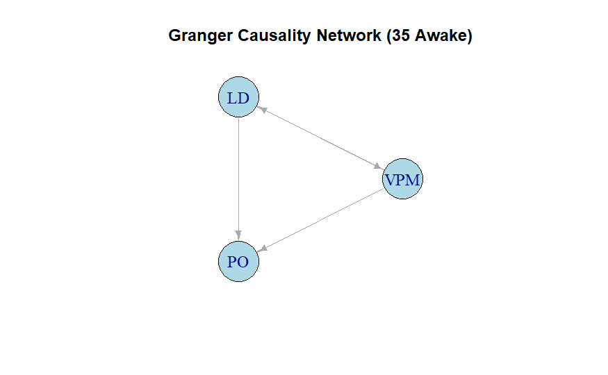

```r
# Required libraries
library(igraph)

# Define nodes
nodes <- c("VPM", "LD", "PO")

# Define edges with significant Granger causality (p < 0.05)
# From the provided results, we have the following significant edges:
edges <- c(
  "VPM", "LD",  # VPM_35_A Granger-causes LD_35_A
  "VPM", "PO",  # VPM_35_A Granger-causes PO_35_A
  "LD", "VPM",  # LD_35_A Granger-causes VPM_35_A
  "LD", "PO"   # LD_35_A Granger-causes PO_35_A
)

# Create a directed graph
g <- graph_from_edgelist(matrix(edges, ncol = 2, byrow = TRUE), directed = TRUE)

# Plot the graph
plot(g,
     vertex.size = 50,
     vertex.label.cex = 1.2,
     vertex.color = "lightblue",
     edge.arrow.size = 0.6,
     main = "Granger Causality Network (35 Awake)",
     layout = layout_in_circle)
```

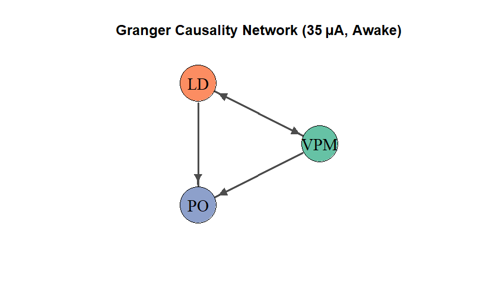

```r
# Load library
library(igraph)

# Define nodes and edges
nodes <- c("VPM", "LD", "PO")
edges <- c(
  "VPM", "LD",  # VPM_35_A Granger-causes LD_35_A
  "VPM", "PO",  # VPM_35_A Granger-causes PO_35_A
  "LD", "VPM",  # LD_35_A Granger-causes VPM_35_A
  "LD", "PO"   # LD_35_A Granger-causes PO_35_A
)

# Create directed graph
g <- graph_from_edgelist(matrix(edges, ncol = 2, byrow = TRUE), directed = TRUE)

# Define colors for clarity
vertex_colors <- c("VPM" = "#66c2a5", "LD" = "#fc8d62", "PO" = "#8da0cb")
edge_colors <- rep("gray30", ecount(g))

# Plot graph with enhancements
plot(g,
     vertex.size = 60,
     vertex.label.cex = 1.4,
     vertex.label.color = "black",
     vertex.color = vertex_colors[V(g)$name],
     edge.arrow.size = 0.9,
     edge.width = 2.5,
     edge.color = edge_colors,
     layout = layout_in_circle,
     main = "Granger Causality Network (35 μA, Awake)"
)
```

### For ISO 35

```r
# Read the CSV file
firing_param35_ISO <- read.csv("F:/mydata/IIT_J/mtech/project/sourav sirs papers/Time series modelling of 100 sequences/data/firing_param35_ISO.csv")

# Create a new data frame with specific columns
df_ISO_35 <- data.frame(
  VPM = firing_param35_ISO$VPM,
  LD = firing_param35_ISO$LD,
  PO = firing_param35_ISO$PO
)

# Set column names explicitly if needed
#colnames(df_ISO_35) <- c("VPM_35_Iso", "LD_35_Iso", "PO_35_Iso")

#plot.ts(df_ISO_35$VPM)

MTSplot(df_ISO_35)
```

[output not shown]

```r
hurstexp(df_ISO_35$VPM)
```

[output not shown]

```r
hurstexp(df_ISO_35$LD)
```

[output not shown]

```r
hurstexp(df_ISO_35$PO)
```

[output not shown]

```r
VARorder(df_ISO_35)
```

[output not shown]

```r
model_ISO_35=VAR(df_ISO_35,p=13)

serial.test(model_ISO_35)
```

[output not shown]

```r
causality(model_ISO_35,"VPM")
causality(model_ISO_35,"LD")
causality(model_ISO_35,"PO")
```

[output not shown]

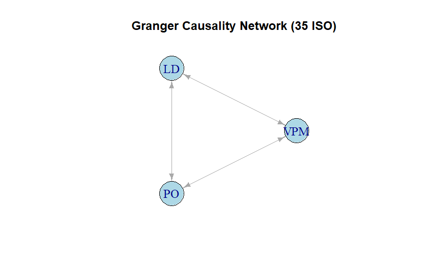

```r
# Required libraries
library(igraph)

# Define nodes
nodes <- c("VPM", "LD", "PO")

# Define edges with significant Granger causality (p < 0.05)
# From the provided results, we have the following significant edges:
edges <- c(
  "VPM", "LD",  # VPM Granger-causes LD
  "VPM", "PO",  # VPM Granger-causes PO
  "LD", "VPM",  # LD Granger-causes VPM
  "LD", "PO",   # LD Granger-causes PO
  "PO", "VPM",  # PO Granger-causes VPM
  "PO", "LD"    # PO Granger-causes LD
)

# Create a directed graph
g <- graph_from_edgelist(matrix(edges, ncol = 2, byrow = TRUE), directed = TRUE)

# Plot the graph
plot(g,
     vertex.size = 40,
     vertex.label.cex = 1.2,
     vertex.color = "lightblue",
     edge.arrow.size = 0.6,
     main = "Granger Causality Network (35 ISO)",
     layout = layout_in_circle)
```

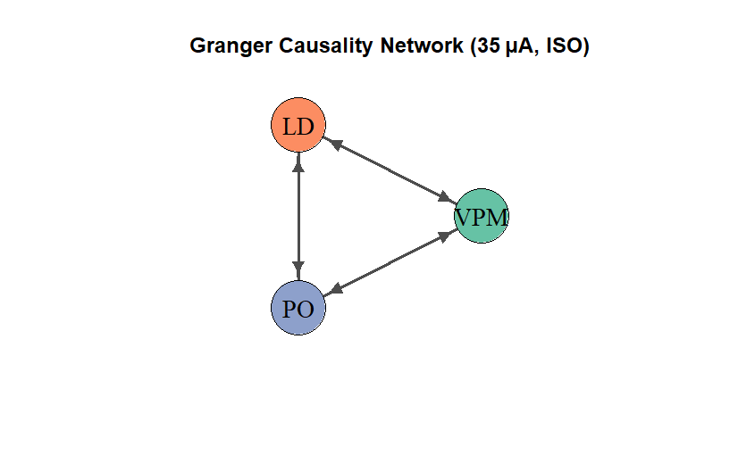

```r
# Load library
library(igraph)

# Define nodes and edges
nodes <- c("VPM", "LD", "PO")
edges <- c(
  "VPM", "LD",  # VPM Granger-causes LD
  "VPM", "PO",  # VPM Granger-causes PO
  "LD", "VPM",  # LD Granger-causes VPM
  "LD", "PO",   # LD Granger-causes PO
  "PO", "VPM",  # PO Granger-causes VPM
  "PO", "LD"    # PO Granger-causes LD
)

# Create directed graph
g <- graph_from_edgelist(matrix(edges, ncol = 2, byrow = TRUE), directed = TRUE)

# Define colors for clarity
vertex_colors <- c("VPM" = "#66c2a5", "LD" = "#fc8d62", "PO" = "#8da0cb")
edge_colors <- rep("gray30", ecount(g))

# Plot graph with enhancements
plot(g,
     vertex.size = 60,
     vertex.label.cex = 1.4,
     vertex.label.color = "black",
     vertex.color = vertex_colors[V(g)$name],
     edge.arrow.size = 0.9,
     edge.width = 2.5,
     edge.color = edge_colors,
     layout = layout_in_circle,
     main = "Granger Causality Network (35 μA, ISO)"
)
```

### Parameter 35 Recovery

```r
# Read the CSV file
firing_param35_Recovery <- read.csv("F:/mydata/IIT_J/mtech/project/sourav sirs papers/Time series modelling of 100 sequences/data/firing_param35_Recovery.csv")

# Create a new data frame with specific columns
df_Recovery_35 <- data.frame(
  VPM = firing_param35_Recovery$VPM,
  LD = firing_param35_Recovery$LD,
  PO = firing_param35_Recovery$PO
)

# Set column names explicitly if needed
#colnames(df_ISO_35) <- c("VPM_35_Iso", "LD_35_Iso", "PO_35_Iso")

#plot.ts(df_ISO_35$VPM)

MTSplot(df_Recovery_35)
```

[output not shown]

### Assessing the long term dependences

```r
hurstexp(df_Recovery_35$VPM)
```

[output not shown]

```r
hurstexp(df_Recovery_35$LD)
```

[output not shown]

```r
hurstexp(df_Recovery_35$PO)
```

[output not shown]

```r
VARorder(df_Recovery_35)
```

[output not shown]

```r
model_Recovery_35=VAR(df_Recovery_35,p=11)
serial.test(model_Recovery_35)
```

[output not shown]

```r
causality(model_Recovery_35,"VPM")
causality(model_Recovery_35,"LD")
causality(model_Recovery_35,"PO")
```

[output not shown]

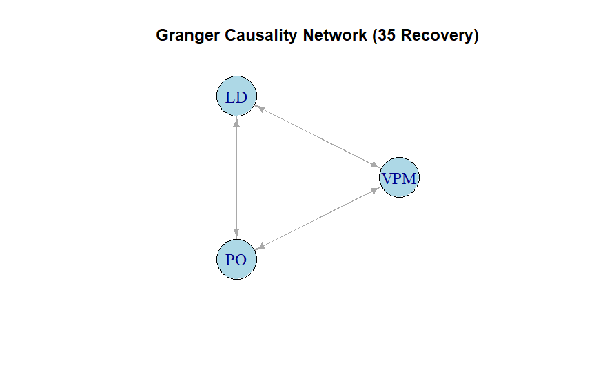

```r
# Required libraries
library(igraph)

# Define nodes
nodes <- c("VPM", "LD", "PO")

# Define edges with significant Granger causality (p < 0.05)
# From the provided results, we have the following significant edges:
edges <- c(
  "VPM", "LD",  # VPM Granger-causes LD
  "VPM", "PO",  # VPM Granger-causes PO
  "LD", "VPM",  # LD Granger-causes VPM
  "LD", "PO",   # LD Granger-causes PO
  "PO", "VPM",  # PO Granger-causes VPM
  "PO", "LD"    # PO Granger-causes LD
)

# Create a directed graph
g <- graph_from_edgelist(matrix(edges, ncol = 2, byrow = TRUE), directed = TRUE)

# Plot the graph
plot(g,
     vertex.size = 50,
     vertex.label.cex = 1.2,
     vertex.color = "lightblue",
     edge.arrow.size = 0.6,
     main = "Granger Causality Network (35 Recovery)",
     layout = layout_in_circle)
```

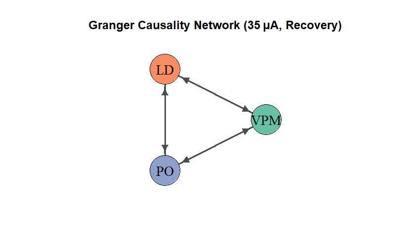

```r
library(igraph)

# Define nodes and edges
nodes <- c("VPM", "LD", "PO")
edges <- c(
  "VPM", "LD",  # VPM Granger-causes LD
  "VPM", "PO",  # VPM Granger-causes PO
  "LD", "VPM",  # LD Granger-causes VPM
  "LD", "PO",   # LD Granger-causes PO
  "PO", "VPM",  # PO Granger-causes VPM
  "PO", "LD"    # PO Granger-causes LD
)

# Create directed graph
g <- graph_from_edgelist(matrix(edges, ncol = 2, byrow = TRUE), directed = TRUE)

# Define colors for clarity
vertex_colors <- c("VPM" = "#66c2a5", "LD" = "#fc8d62", "PO" = "#8da0cb")
edge_colors <- rep("gray30", ecount(g))

# Plot graph with enhancements
plot(g,
     vertex.size = 60,
     vertex.label.cex = 1.4,
     vertex.label.color = "black",
     vertex.color = vertex_colors[V(g)$name],
     edge.arrow.size = 0.9,
     edge.width = 2.5,
     edge.color = edge_colors,
     layout = layout_in_circle,
     main = "Granger Causality Network (35 μA, Recovery)"
)
```

### Parameter 60

```r
# Read the CSV file
firing_param60_Awake <- read.csv("F:/mydata/IIT_J/mtech/project/sourav sirs papers/Time series modelling of 100 sequences/data/firing_param60_Awake.csv")

# Create a new data frame with specific columns
df_Awake_60 <- data.frame(
  VPM = firing_param60_Awake$VPM,
  LD = firing_param60_Awake$LD,
  PO = firing_param60_Awake$PO
)

# Set column names explicitly if needed
#colnames(df_ISO_35) <- c("VPM_35_Iso", "LD_35_Iso", "PO_35_Iso")

#plot.ts(df_ISO_35$VPM)

MTSplot(df_Awake_60)
```

[output not shown]

```r
hurstexp(df_Awake_60$VPM)
```

[output not shown]

```r
hurstexp(df_Awake_60$LD)
```

[output not shown]

```r
hurstexp(df_Awake_60$PO)
```

[output not shown]

```r
VARorder(df_Awake_60)
```

[output not shown]

```r
model_Awake_60=VAR(df_Awake_60,p=13)
serial.test(model_Awake_60)

causality(model_Awake_60,"VPM")
causality(model_Awake_60,"LD")
causality(model_Awake_60,"PO")
```

[output not shown]

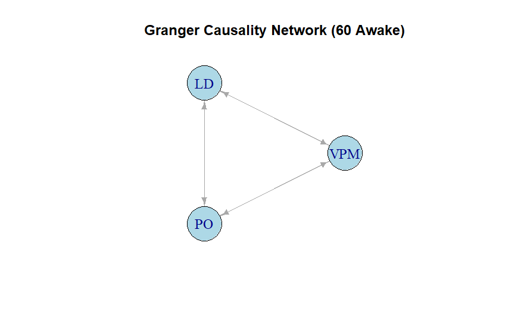

```r
# Required libraries
library(igraph)

# Define nodes
nodes <- c("VPM", "LD", "PO")

# Define edges with significant Granger causality (p < 0.05)
# From the provided results, we have the following significant edges:
edges <- c(
  "VPM", "LD",  # VPM Granger-causes LD
  "VPM", "PO",  # VPM Granger-causes PO
  "LD", "VPM",  # LD Granger-causes VPM
  "LD", "PO",   # LD Granger-causes PO
  "PO", "VPM",  # PO Granger-causes VPM
  "PO", "LD"    # PO Granger-causes LD
)

# Create a directed graph
g <- graph_from_edgelist(matrix(edges, ncol = 2, byrow = TRUE), directed = TRUE)

# Plot the graph
plot(g,
     vertex.size = 50,
     vertex.label.cex = 1.2,
     vertex.color = "lightblue",
     edge.arrow.size = 0.6,
     main = "Granger Causality Network (60 Awake)",
     layout = layout_in_circle)
```

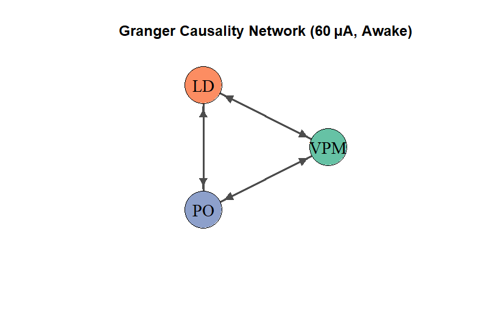

```r
library(igraph)

# Define nodes and edges
nodes <- c("VPM", "LD", "PO")
edges <- c(
  "VPM", "LD",  # VPM Granger-causes LD
  "VPM", "PO",  # VPM Granger-causes PO
  "LD", "VPM",  # LD Granger-causes VPM
  "LD", "PO",   # LD Granger-causes PO
  "PO", "VPM",  # PO Granger-causes VPM
  "PO", "LD"    # PO Granger-causes LD
)

# Create directed graph
g <- graph_from_edgelist(matrix(edges, ncol = 2, byrow = TRUE), directed = TRUE)

# Define colors for clarity
vertex_colors <- c("VPM" = "#66c2a5", "LD" = "#fc8d62", "PO" = "#8da0cb")
edge_colors <- rep("gray30", ecount(g))

# Plot graph with enhancements
plot(g,
     vertex.size = 60,
     vertex.label.cex = 1.4,
     vertex.label.color = "black",
     vertex.color = vertex_colors[V(g)$name],
     edge.arrow.size = 0.9,
     edge.width = 2.5,
     edge.color = edge_colors,
     layout = layout_in_circle,
     main = "Granger Causality Network (60 μA, Awake)"
)
```

```r
# Read the CSV file
firing_param60_ISO <- read.csv("F:/mydata/IIT_J/mtech/project/sourav sirs papers/Time series modelling of 100 sequences/data/firing_param60_ISO.csv")

# Create a new data frame with specific columns
df_ISO_60 <- data.frame(
  VPM = firing_param60_ISO$VPM,
  LD = firing_param60_ISO$LD,
  PO = firing_param60_ISO$PO
)

# Set column names explicitly if needed
#colnames(df_ISO_35) <- c("VPM_35_Iso", "LD_35_Iso", "PO_35_Iso")

#plot.ts(df_ISO_35$VPM)

MTSplot(df_ISO_60)
```

[output not shown]

```r
hurstexp(df_ISO_60$VPM)
```

[output not shown]

```r
hurstexp(df_ISO_60$LD)
```

[output not shown]

```r
hurstexp(df_ISO_60$PO)
```

[output not shown]

```r
VARorder(df_ISO_60)
```

[output not shown]

```r
model_ISO_60=VAR(df_ISO_60,p=5)
serial.test(model_ISO_60)


causality(model_ISO_60,"VPM")
causality(model_ISO_60,"LD")
causality(model_ISO_60,"PO")
```

[output not shown]

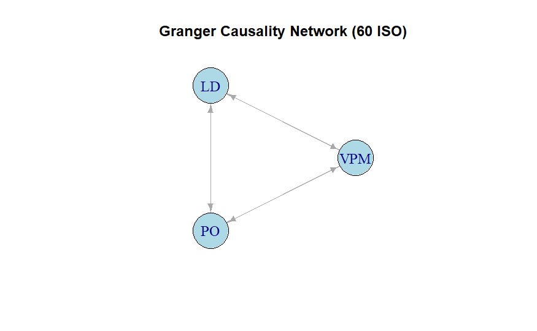

```r
# Required libraries
library(igraph)

# Define nodes
nodes <- c("VPM", "LD", "PO")

# Define edges with significant Granger causality (p < 0.05)
# From the provided results, we have the following significant edges:
edges <- c(
  "VPM", "LD",  # VPM Granger-causes LD
  "VPM", "PO",  # VPM Granger-causes PO
  "LD", "VPM",  # LD Granger-causes VPM
  "LD", "PO",   # LD Granger-causes PO
  "PO", "VPM",  # PO Granger-causes VPM
  "PO", "LD"    # PO Granger-causes LD
)

# Create a directed graph
g <- graph_from_edgelist(matrix(edges, ncol = 2, byrow = TRUE), directed = TRUE)

# Plot the graph
plot(g,
     vertex.size = 50,
     vertex.label.cex = 1.2,
     vertex.color = "lightblue",
     edge.arrow.size = 0.6,
     main = "Granger Causality Network (60 ISO)",
     layout = layout_in_circle)
```

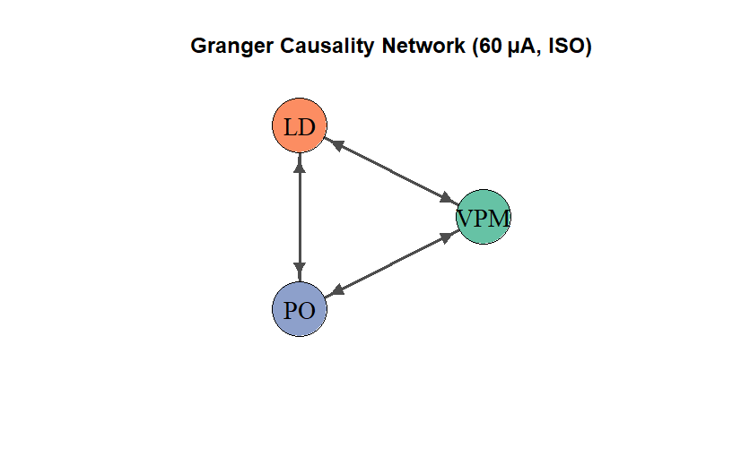

```r
library(igraph)

# Define nodes and edges
nodes <- c("VPM", "LD", "PO")
edges <- c(
  "VPM", "LD",  # VPM Granger-causes LD
  "VPM", "PO",  # VPM Granger-causes PO
  "LD", "VPM",  # LD Granger-causes VPM
  "LD", "PO",   # LD Granger-causes PO
  "PO", "VPM",  # PO Granger-causes VPM
  "PO", "LD"    # PO Granger-causes LD
)

# Create directed graph
g <- graph_from_edgelist(matrix(edges, ncol = 2, byrow = TRUE), directed = TRUE)

# Define colors for clarity
vertex_colors <- c("VPM" = "#66c2a5", "LD" = "#fc8d62", "PO" = "#8da0cb")
edge_colors <- rep("gray30", ecount(g))

# Plot graph with enhancements
plot(g,
     vertex.size = 60,
     vertex.label.cex = 1.4,
     vertex.label.color = "black",
     vertex.color = vertex_colors[V(g)$name],
     edge.arrow.size = 0.9,
     edge.width = 2.5,
     edge.color = edge_colors,
     layout = layout_in_circle,
     main = "Granger Causality Network (60 μA, ISO)"
)
```

```r
# Read the CSV file
firing_param60_Recovery <- read.csv("F:/mydata/IIT_J/mtech/project/sourav sirs papers/Time series modelling of 100 sequences/data/firing_param60_Recovery.csv")

# Create a new data frame with specific columns
df_Recovery_60 <- data.frame(
  VPM = firing_param60_Recovery$VPM,
  LD = firing_param60_Recovery$LD,
  PO = firing_param60_Recovery$PO
)

# Set column names explicitly if needed
#colnames(df_ISO_35) <- c("VPM_35_Iso", "LD_35_Iso", "PO_35_Iso")

#plot.ts(df_ISO_35$VPM)

MTSplot(df_Recovery_60)
```

[output not shown]

```r
hurstexp(df_Recovery_60$VPM)


hurstexp(df_Recovery_60$LD)

hurstexp(df_Recovery_60$PO)
```

[output not shown]

```r
VARorder(df_Recovery_60)
```

[output not shown]

```r
model_Recovery_60=VAR(df_Recovery_60,p=13)
serial.test(model_Recovery_60)


causality(model_Recovery_60,"VPM")
causality(model_Recovery_60,"LD")
causality(model_Recovery_60,"PO")
```

[output not shown]

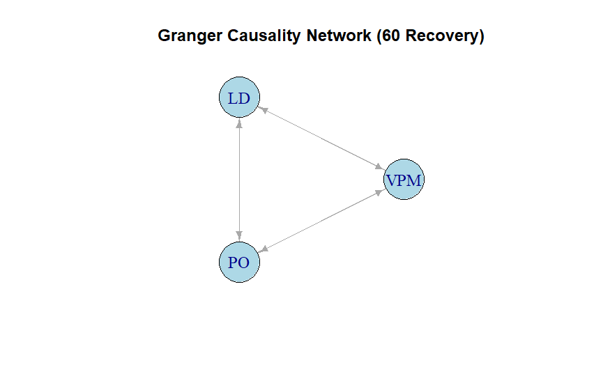

```r
# Define nodes
nodes <- c("VPM", "LD", "PO")

# Define edges with significant Granger causality (p < 0.05)
# From the provided results, we have the following significant edges:
edges <- c(
  "VPM", "LD",  # VPM Granger-causes LD
  "VPM", "PO",  # VPM Granger-causes PO
  "LD", "VPM",  # LD Granger-causes VPM
  "LD", "PO",   # LD Granger-causes PO
  "PO", "VPM",  # PO Granger-causes VPM
  "PO", "LD"    # PO Granger-causes LD
)

# Create a directed graph
g <- graph_from_edgelist(matrix(edges, ncol = 2, byrow = TRUE), directed = TRUE)

# Plot the graph
plot(g,
     vertex.size = 50,
     vertex.label.cex = 1.2,
     vertex.color = "lightblue",
     edge.arrow.size = 0.6,
     main = "Granger Causality Network (60 Recovery)",
     layout = layout_in_circle)
```

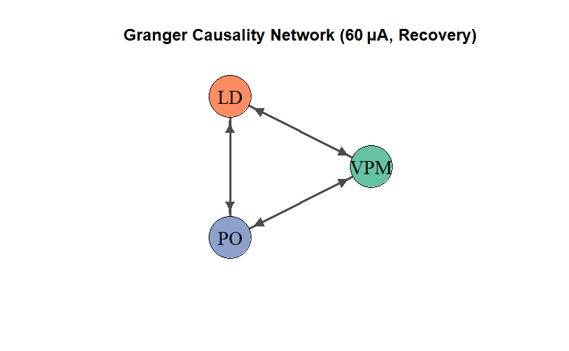

```r
library(igraph)

# Define nodes and edges
nodes <- c("VPM", "LD", "PO")
edges <- c(
  "VPM", "LD",  # VPM Granger-causes LD
  "VPM", "PO",  # VPM Granger-causes PO
  "LD", "VPM",  # LD Granger-causes VPM
  "LD", "PO",   # LD Granger-causes PO
  "PO", "VPM",  # PO Granger-causes VPM
  "PO", "LD"    # PO Granger-causes LD
)

# Create directed graph
g <- graph_from_edgelist(matrix(edges, ncol = 2, byrow = TRUE), directed = TRUE)

# Define colors for clarity
vertex_colors <- c("VPM" = "#66c2a5", "LD" = "#fc8d62", "PO" = "#8da0cb")
edge_colors <- rep("gray30", ecount(g))

# Plot graph with enhancements
plot(g,
     vertex.size = 60,
     vertex.label.cex = 1.4,
     vertex.label.color = "black",
     vertex.color = vertex_colors[V(g)$name],
     edge.arrow.size = 0.9,
     edge.width = 2.5,
     edge.color = edge_colors,
     layout = layout_in_circle,
     main = "Granger Causality Network (60 μA, Recovery)"
)
```